# Wine quality analysis

bx17

3/23/2020

这份报告探索一个包含4898种葡萄酒的质量和各种变量的数据集。

中英文对照：

| 1 - fixed acidity (tartaric acid - g / dm^3) | 非挥发性酸度 |
| --- | --- |
| 2 - volatile acidity (acetic acid - g / dm^3) | 挥发性酸度 |
| 3 - citric acid (g / dm^3) | 柠檬酸 |
| 4 - residual sugar (g / dm^3) | 剩余糖分 |
| 5 - chlorides (sodium chloride - g / dm^3 | 氯化钠 |
| 6 - free sulfur dioxide (mg / dm^3) | 游离二氧化硫 |
| 7 - total sulfur dioxide (mg / dm^3) | 总二氧化硫 |
| 8 - density (g / cm^3) | 密度 |
| 9 - pH | 酸碱度 |
| 10 - sulphates (potassium sulphate - g / dm3) | 硫酸盐 |
| 11 - alcohol (% by volume) | 酒精度 |
| Output variable (based on sensory data): |  |
| 12 - quality (score between 0 and 10) | 质量 |

# 单变量绘图选择

```
## [1] 4898
```

```
## [1] 13
```

```
## 'data.frame':    4898 obs. of  13 variables:
##  $ X                   : int  1 2 3 4 5 6 7 8 9 10 ...
##  $ fixed.acidity       : num  7 6.3 8.1 7.2 7.2 8.1 6.2 7 6.3 8.1 ...
##  $ volatile.acidity    : num  0.27 0.3 0.28 0.23 0.23 0.28 0.32 0.27 0.3 0.22 ...
##  $ citric.acid         : num  0.36 0.34 0.4 0.32 0.32 0.4 0.16 0.36 0.34 0.43 ...
##  $ residual.sugar      : num  20.7 1.6 6.9 8.5 8.5 6.9 7 20.7 1.6 1.5 ...
##  $ chlorides           : num  0.045 0.049 0.05 0.058 0.058 0.05 0.045 0.045 0.049 0.044 ...
##  $ free.sulfur.dioxide : num  45 14 30 47 47 30 30 45 14 28 ...
##  $ total.sulfur.dioxide: num  170 132 97 186 186 97 136 170 132 129 ...
##  $ density             : num  1.001 0.994 0.995 0.996 0.996 ...
##  $ pH                  : num  3 3.3 3.26 3.19 3.19 3.26 3.18 3 3.3 3.22 ...
##  $ sulphates           : num  0.45 0.49 0.44 0.4 0.4 0.44 0.47 0.45 0.49 0.45 ...
##  $ alcohol             : num  8.8 9.5 10.1 9.9 9.9 10.1 9.6 8.8 9.5 11 ...
##  $ quality             : int  6 6 6 6 6 6 6 6 6 6 ...
```

```
##        X        fixed.acidity    volatile.acidity  citric.acid
##  Min.   :   1   Min.   : 3.800   Min.   :0.0800   Min.   :0.0000
##  1st Qu.:1225   1st Qu.: 6.300   1st Qu.:0.2100   1st Qu.:0.2700
##  Median :2450   Median : 6.800   Median :0.2600   Median :0.3200
##  Mean   :2450   Mean   : 6.855   Mean   :0.2782   Mean   :0.3342
##  3rd Qu.:3674   3rd Qu.: 7.300   3rd Qu.:0.3200   3rd Qu.:0.3900
##  Max.   :4898   Max.   :14.200   Max.   :1.1000   Max.   :1.6600
##  residual.sugar     chlorides       free.sulfur.dioxide total.sulfur.dioxide
##  Min.   : 0.600   Min.   :0.00900   Min.   :  2.00      Min.   :  9.0
##  1st Qu.: 1.700   1st Qu.:0.03600   1st Qu.: 23.00      1st Qu.:108.0
##  Median : 5.200   Median :0.04300   Median : 34.00      Median :134.0
##  Mean   : 6.391   Mean   :0.04577   Mean   : 35.31      Mean   :138.4
##  3rd Qu.: 9.900   3rd Qu.:0.05000   3rd Qu.: 46.00      3rd Qu.:167.0
##  Max.   :65.800   Max.   :0.34600   Max.   :289.00      Max.   :440.0
##     density             pH          sulphates         alcohol
##  Min.   :0.9871   Min.   :2.720   Min.   :0.2200   Min.   : 8.00
##  1st Qu.:0.9917   1st Qu.:3.090   1st Qu.:0.4100   1st Qu.: 9.50
##  Median :0.9937   Median :3.180   Median :0.4700   Median :10.40
##  Mean   :0.9940   Mean   :3.188   Mean   :0.4898   Mean   :10.51
##  3rd Qu.:0.9961   3rd Qu.:3.280   3rd Qu.:0.5500   3rd Qu.:11.40
##  Max.   :1.0390   Max.   :3.820   Max.   :1.0800   Max.   :14.20
##     quality
##  Min.   :3.000
##  1st Qu.:5.000
##  Median :6.000
##  Mean   :5.878
##  3rd Qu.:6.000
##  Max.   :9.000
```

数据及包含有13个变量的4898个观测值。

## 非挥发性酸度

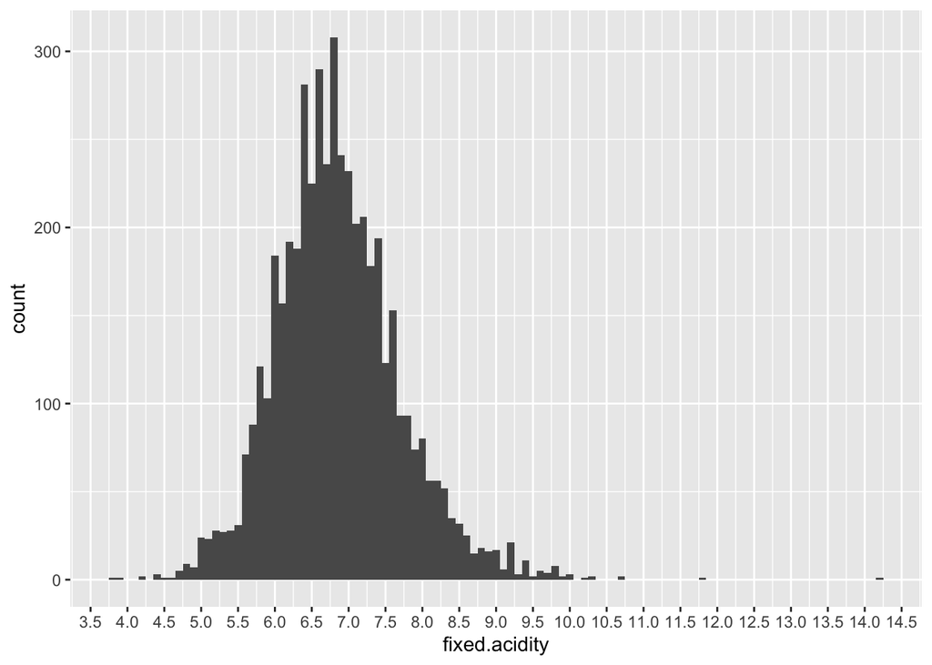

非挥发性酸呈正态分布。低于4.5和高于10的值或为离散值。

## 挥发性酸度

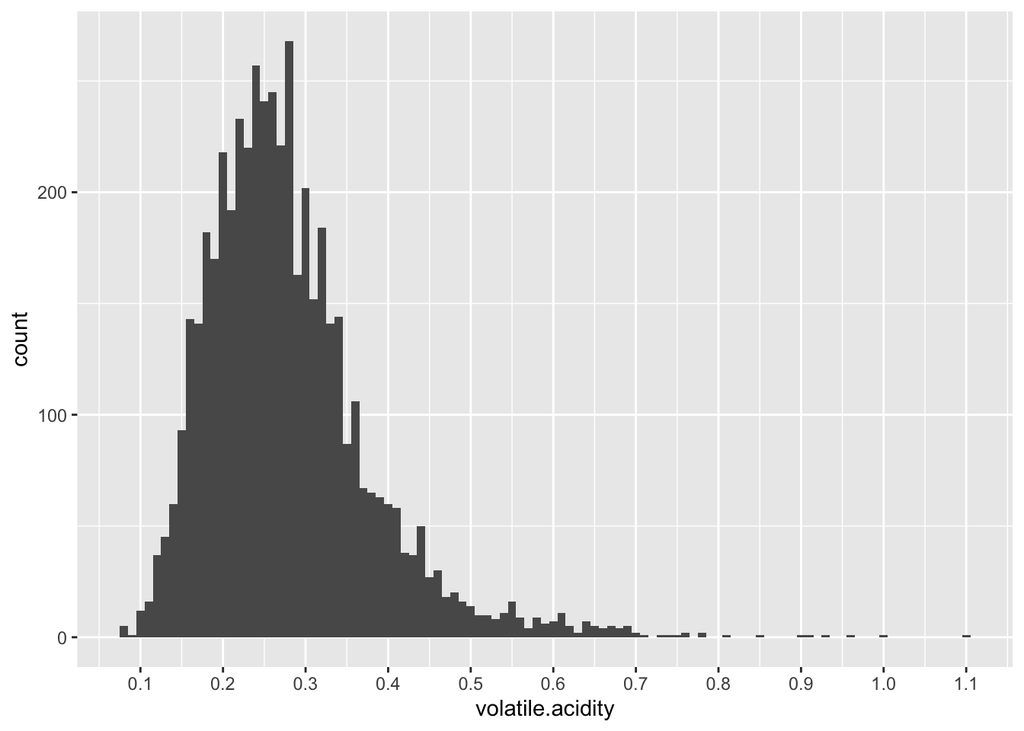

相对于非挥发性酸，挥发性酸较为右偏态分布。高于0.7的值或为离散值。

## 柠檬酸

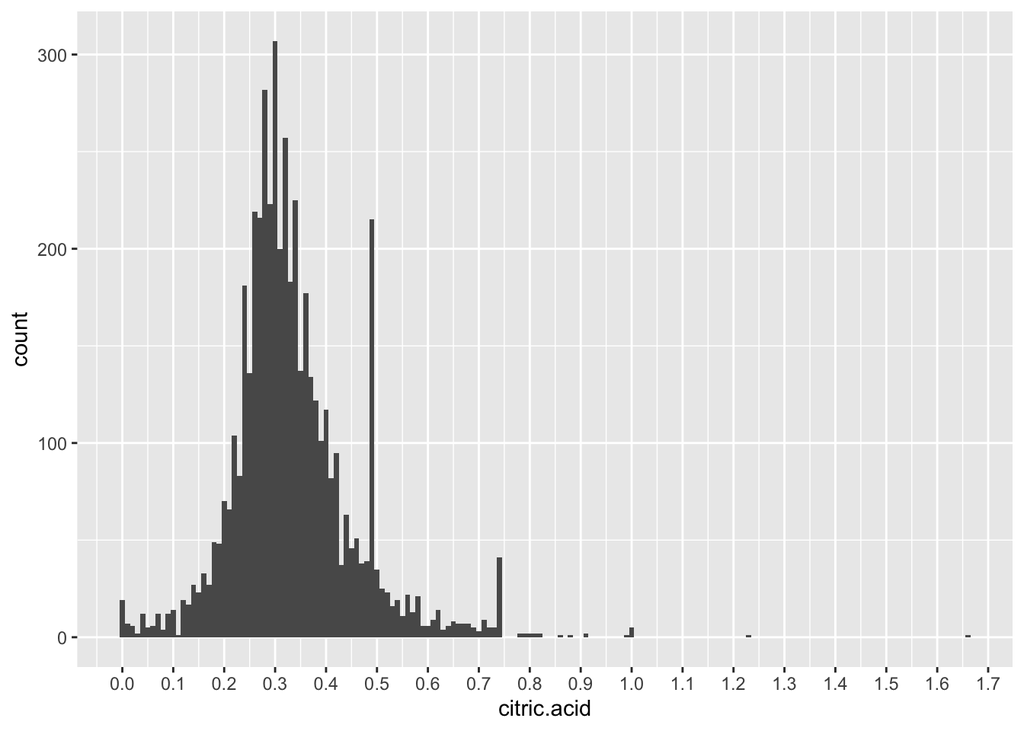

柠檬酸基本呈正态分布。在0.48和0.74处有集中的分布。

## 剩余糖分

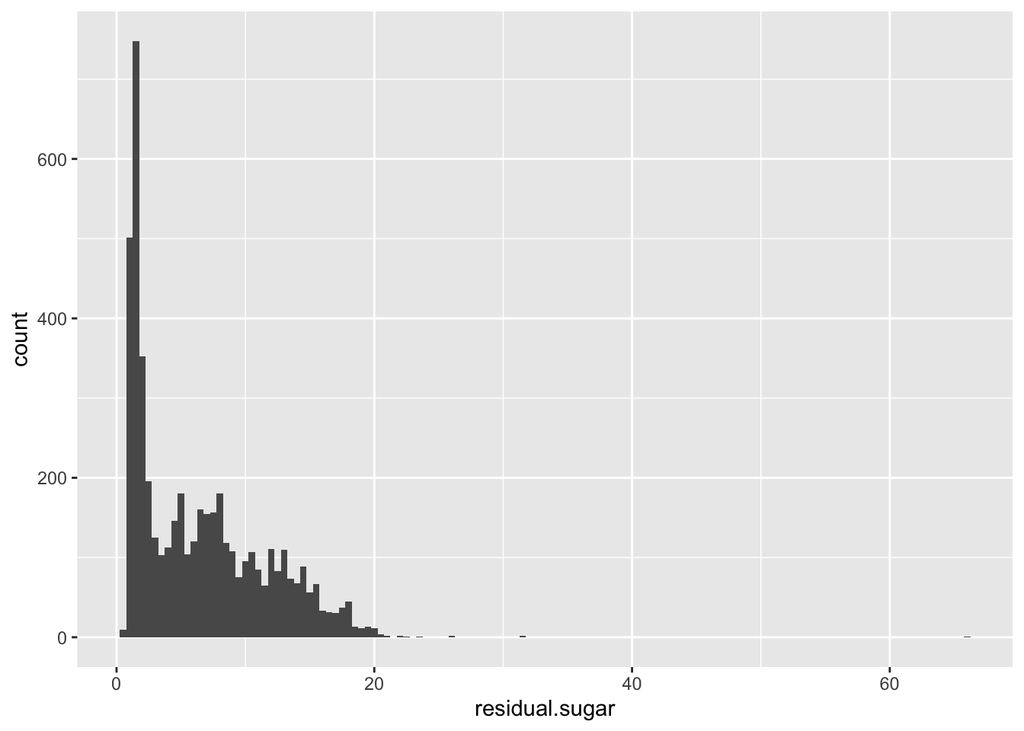

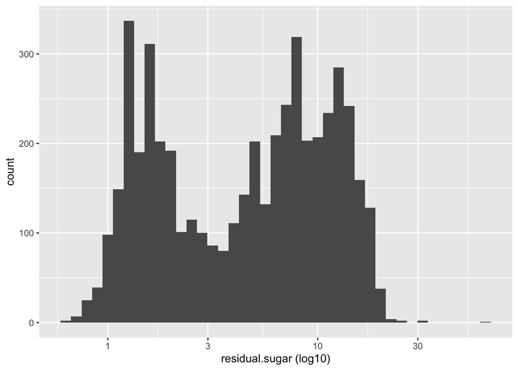

剩余糖分呈明显的右偏态分布。经过log10转换之后发现图形呈双峰趋势。

## 氯化钠

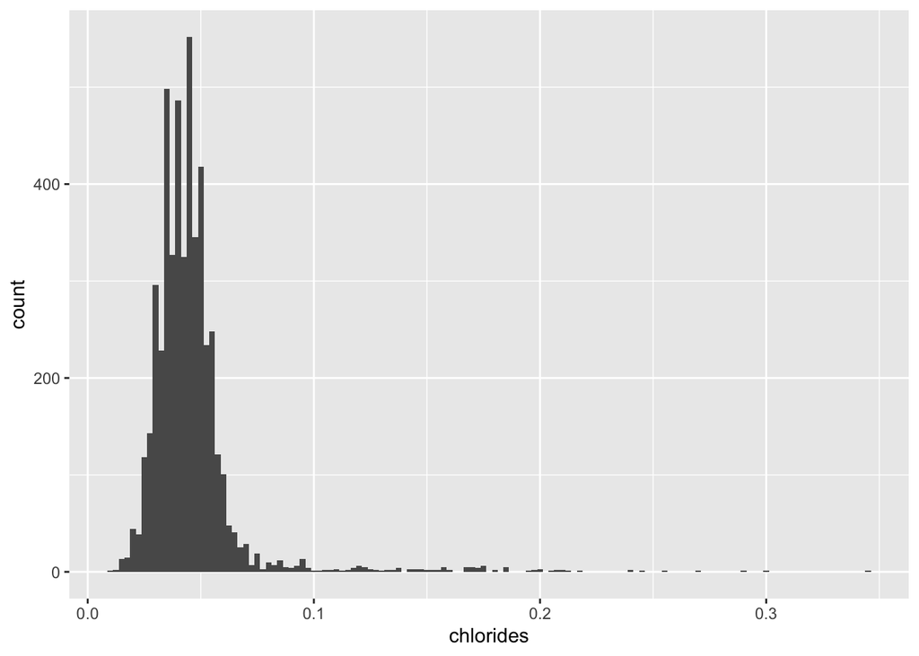

氯化钠呈右偏态分布，右侧的尾巴很长。

## 游离二氧化硫

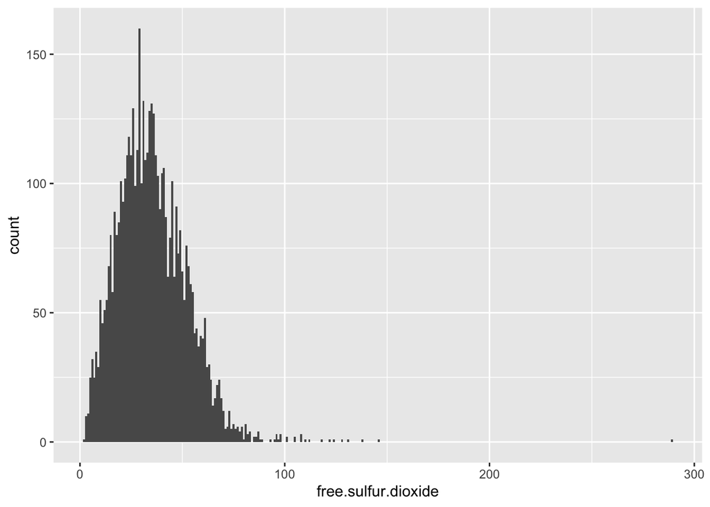

游离二氧化硫大致呈正态分布。高于100的值或为离散值。

## 总二氧化硫

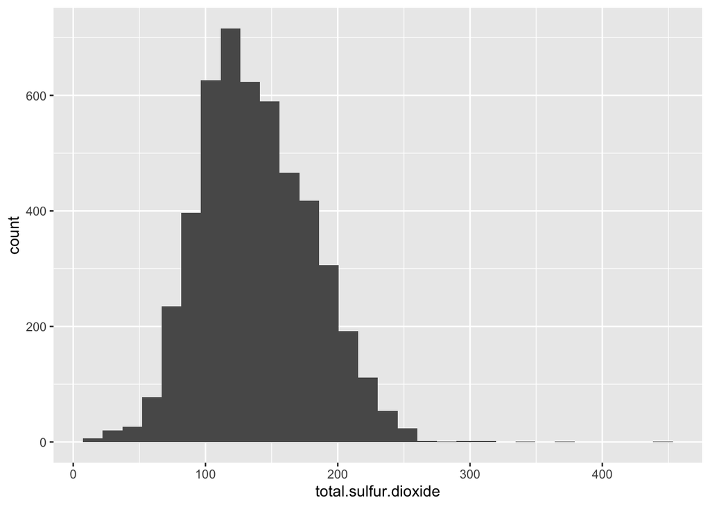

总二氧化硫大致呈正态分布。高于300的或为离散值。

## 密度

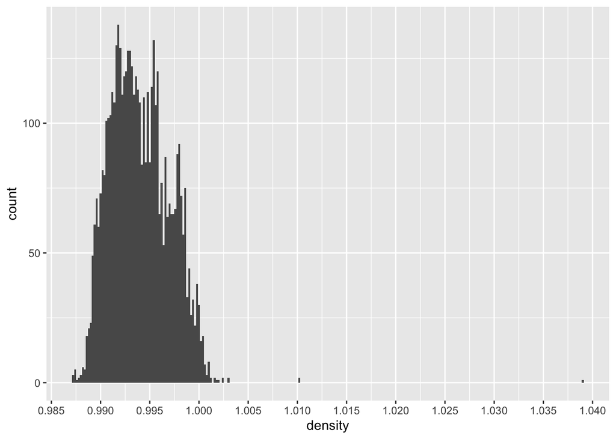

大致呈正态分布。高于1.005的或为离散值。在0.995和0.997处有低谷。

## 酸碱度

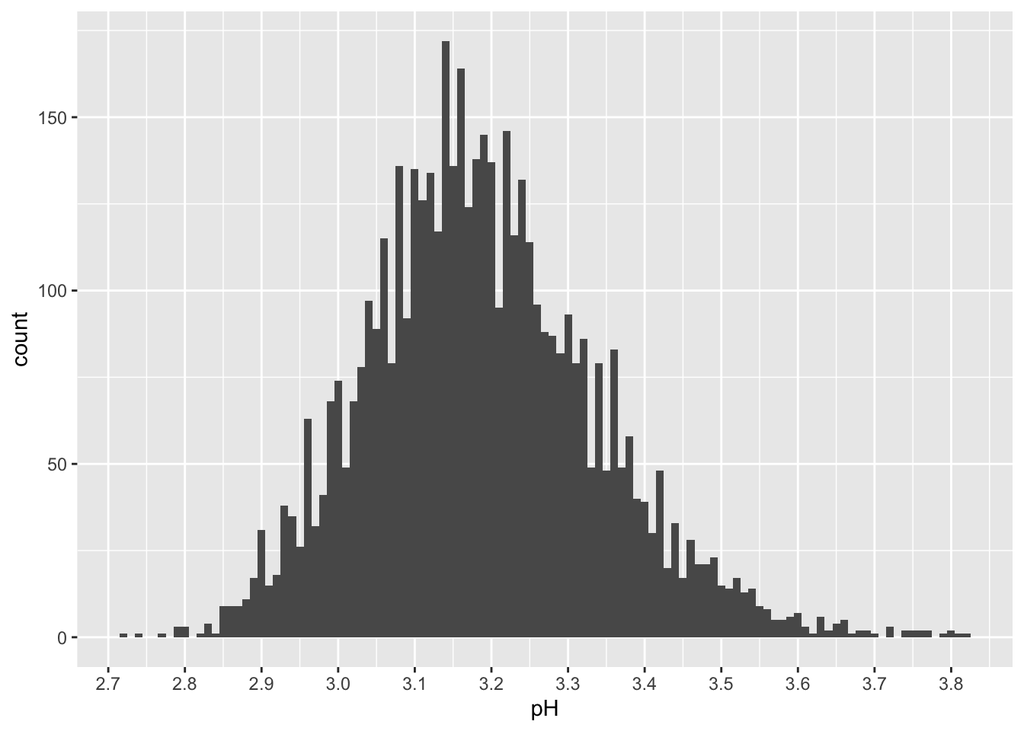

呈正态分布且没有明显的离散值。

## 硫酸盐

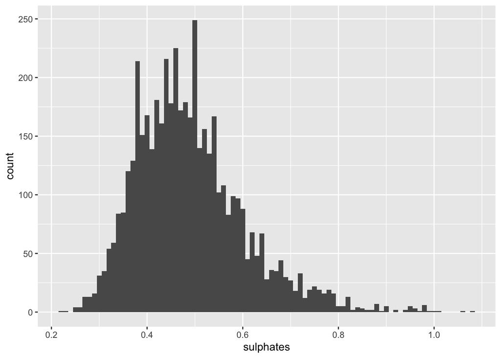

呈右偏态分布。

## 酒精度

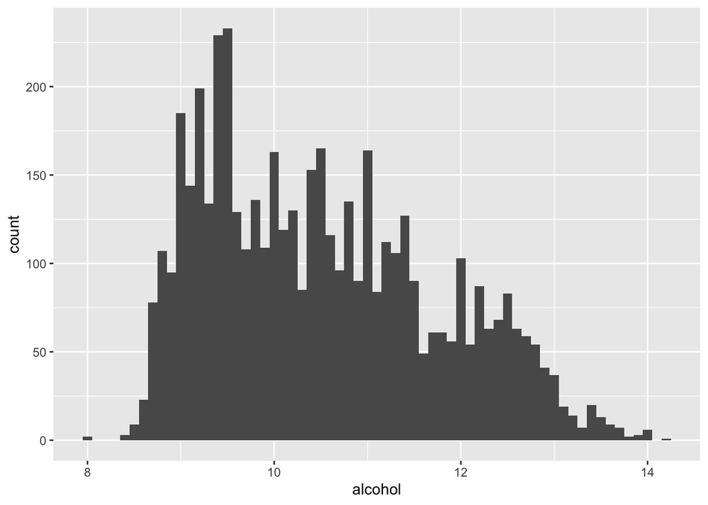

呈右偏态分布。

## 质量

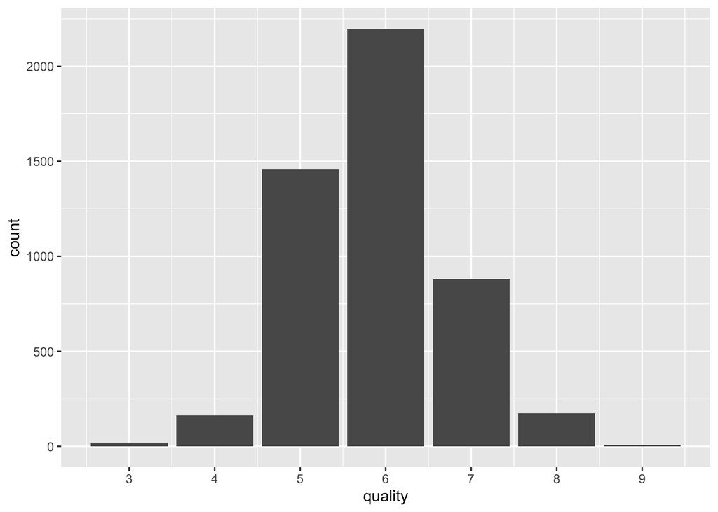

```
##    Min. 1st Qu.  Median    Mean 3rd Qu.    Max.
##   3.000   5.000   6.000   5.878   6.000   9.000
```

质量呈正态分布。大部分的质量处于5至7之间。

# 单变量分析

### 你的数据集结构是什么？

数据集包含有13个特征（非挥发性酸度，挥发性酸度，柠檬酸，剩余糖分，氯化钠，游离二氧化硫，总二氧化硫，密度，酸碱度，硫酸盐，酒精度质量，质量）的4898个葡萄酒。“质量”如下所示是有序的。

（非常差）——————>（非常出色） 质量：0，1，2，3，4，5，6，7，8，9，10。

其他观察结果： - 非挥发性酸度，柠檬酸，氯化钠，游离二氧化硫，总二氧化硫，密度，酸碱度为（长尾）正态分布。 - 挥发性酸度，剩余糖分，酒精度为右偏分布。 - 硫酸盐为轻微的右偏分布。 - 大部分的葡萄酒质量为5~7。

### 你的数据集内感兴趣的主要特性有哪些？

质量（quality）。

### 你认为数据集内哪些其他特征可以帮助你探索兴趣特点？

挥发性酸度，剩余糖分，酒精度，和硫酸盐可以帮助我探索兴趣特点，因为呈右偏分布。

### 根据数据集内已有变量，你是否创建了任何新变量？

否。

### 在已经探究的特性中，是否存在任何异常分布？你是否对数据进行一些操作，如清洁、调整或改变数据的形式？如果是，你为什么会这样做？

# 双变量绘图选择

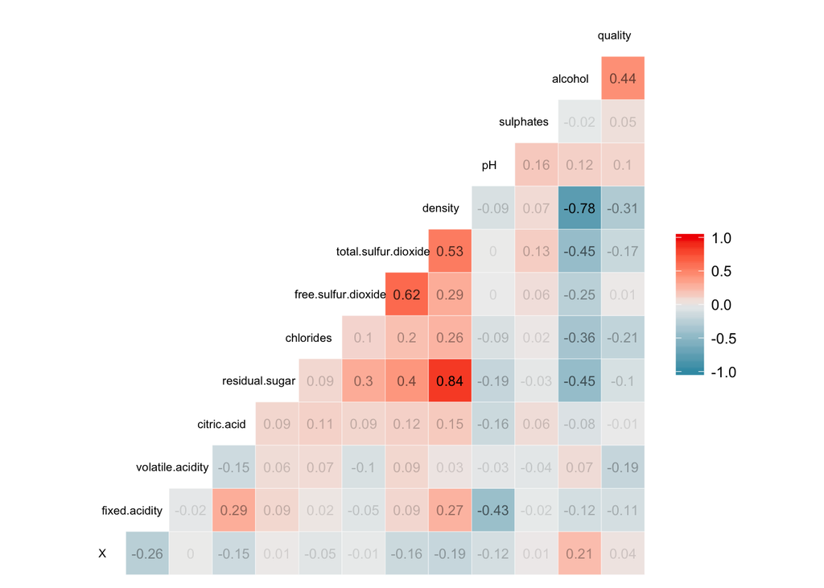

与质量相关性较强的特征： - alcohol 酒精度 - 0.44 - density 密度 - -0.31 - total.sulfur.dioxide 总二氧化硫 - -0.17 - chlorides 氯化钠 - -0.21 - volatile.acidity 挥发性酸度 - -0.19

其他相关性较强的特征： - 密度和酒精度， - -0.78 - 密度和剩余糖分 - 0.84

## 质量与酒精度

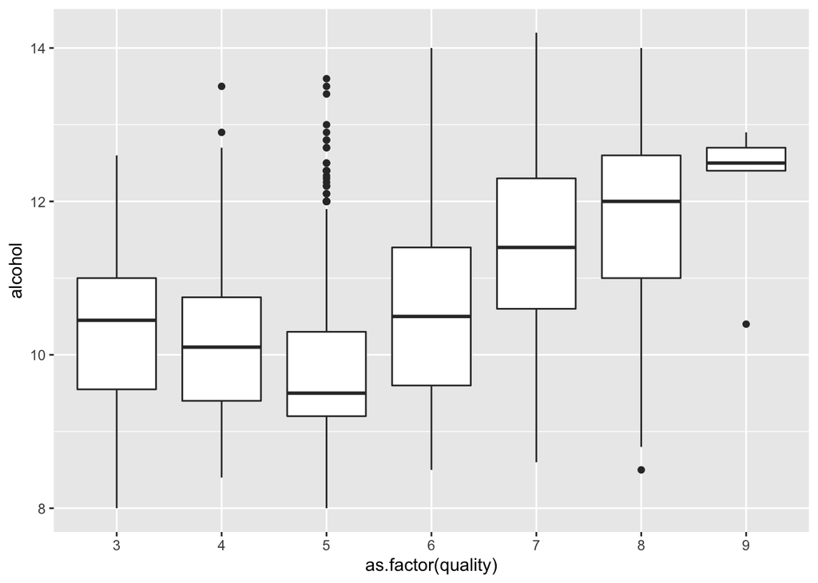

## 质量与密度

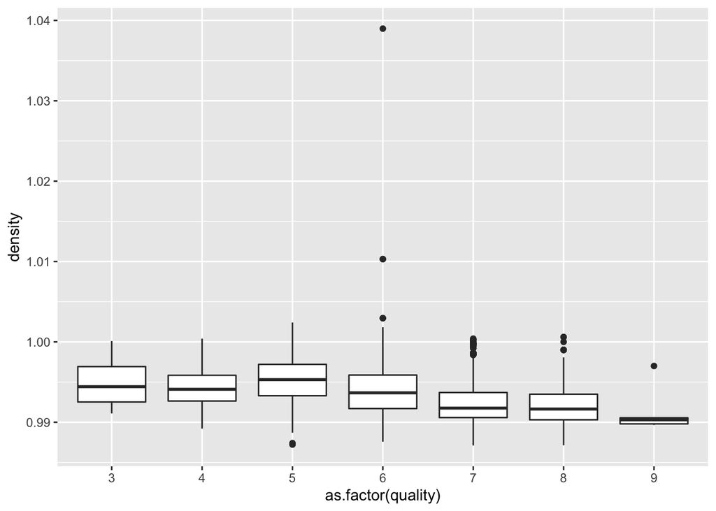

由图可见，质量为9的酒密度波动最小，3、5、6较大，4、7、8适中。质量5-9的红酒有异常值；尤其是质量为6的密度有非常明显的异常值；除了5其他质量的异常值均在上限上方。总体来说质量高的酒密度相对低。

## 质量与氯化钠

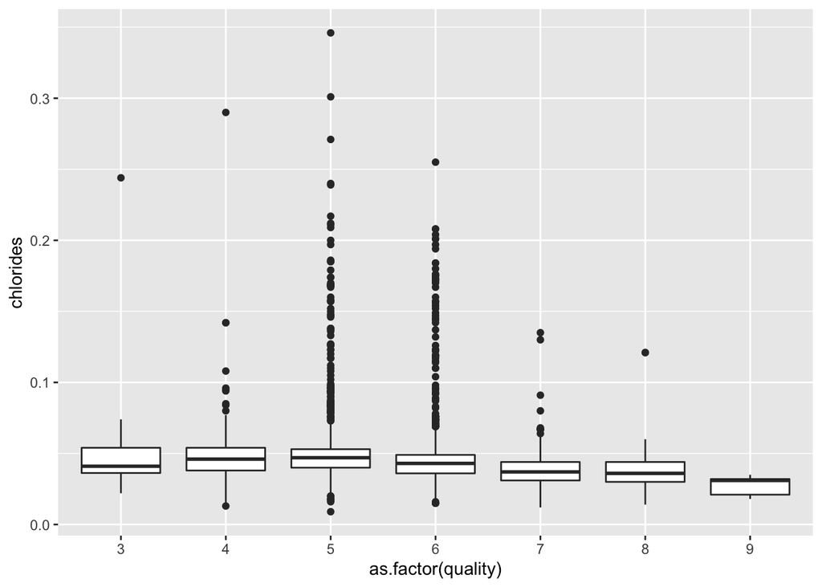

由图可见，除了9之外都有异常值，其中质量为5、6的酒的氯化钠的异常值尤其多。

## 质量与总二氧化硫

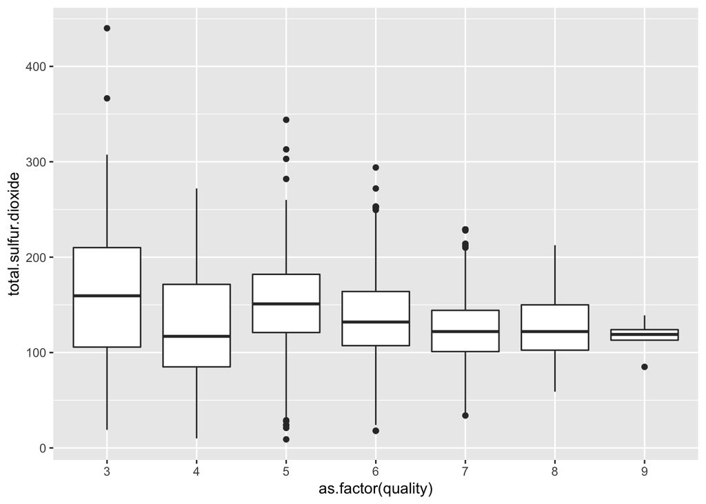

## 质量与挥发性酸度

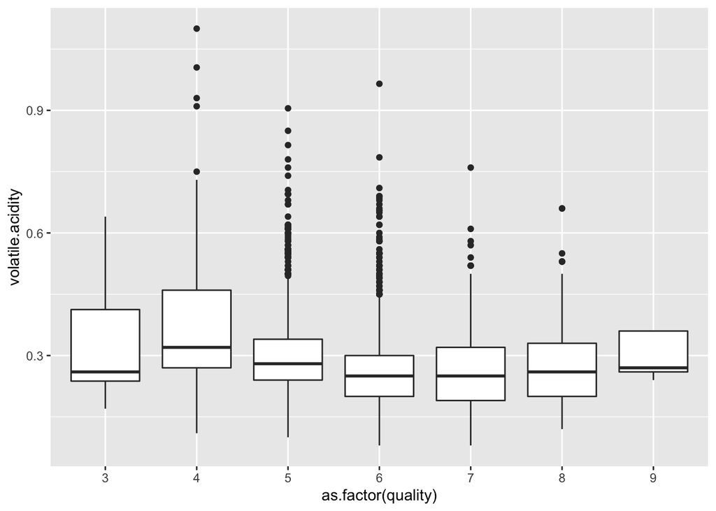

## 密度和酒精度

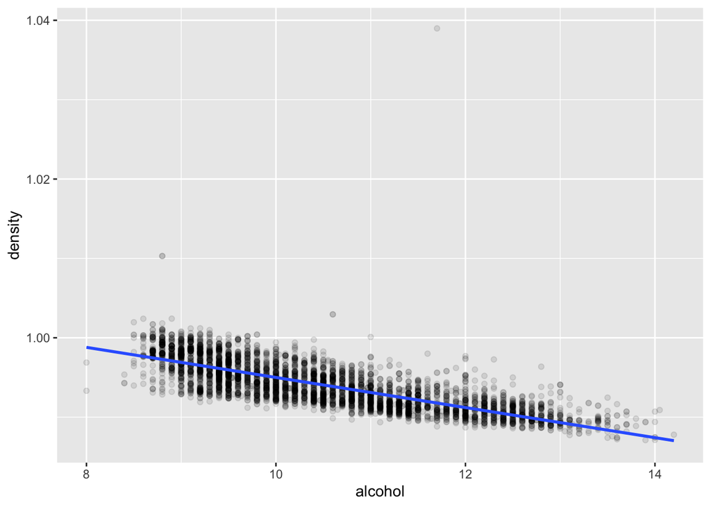

由图可见，二者为负相关。

## 密度和剩余糖分。

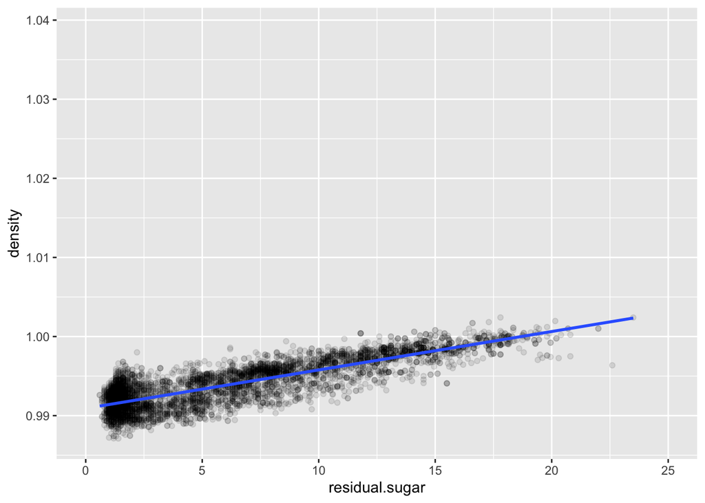

由图可见，二者为正相关。

# 双变量分析

### 探讨你在这部分探究中观察到的一些关系。这些感兴趣的特性与数据集内其他特性有什么区别？Talk about some of the relationships you observed in this part of the investigation. How did the feature(s) of interest vary with other features in the dataset?

质量与酒精度呈正向关，与密度、总二氧化硫、氯化钠、挥发性酸度呈负相关。

### 你是否观察到主要特性与其他特性之间的有趣关系？Did you observe any interesting relationships between the other features (not the main feature(s) of interest)?

密度和酒精度呈较强的负相关、与剩余糖分呈较强正相关。

### 你发现最强的关系是什么？

密度和剩余糖分。

# 多变量绘图选择

## 密度、酒精度、质量

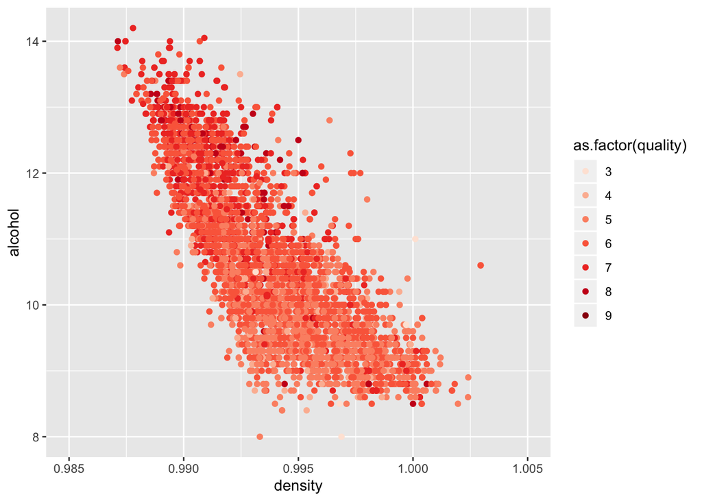

## 密度、剩余糖分、质量

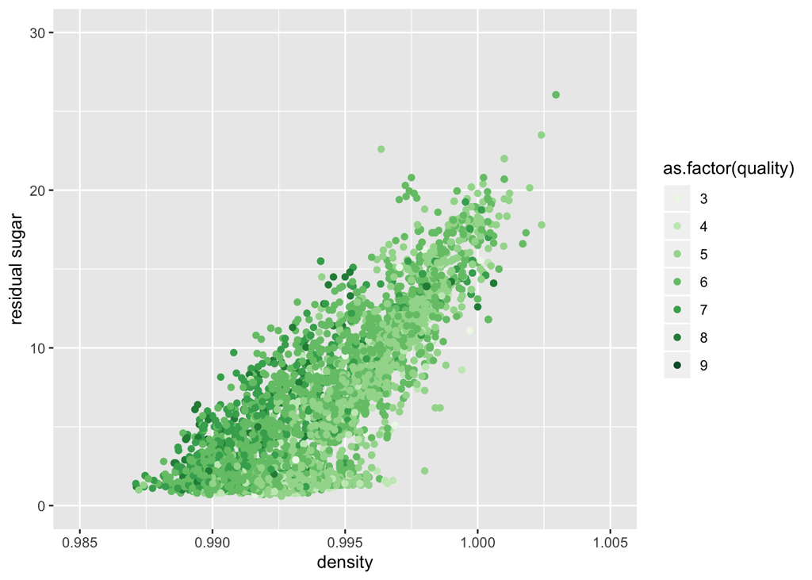

# 多变量分析

### 探讨你在这部分探究中观察到的一些关系。通过观察感兴趣的特性，是否存在相互促进的特性？Talk about some of the relationships you observed in this part of the investigation. Were there features that strengthened each other in terms of looking at your feature(s) of interest?

靠上的部分深色（质量较高）的点比较多。

### 这些特性之间是否存在有趣或惊人的联系呢？Were there any interesting or surprising interactions between features?

密度和酒精度的关系 和 密度和剩余糖分 的关系是“相反”（一个呈正相关，一个呈负相关）的，而质量在两幅图中的相对位置是相同的（都是靠上的部分深色点较多）。

### 选项：你是否创建过数据集的任何模型？讨论你模型的优缺点。

# 定稿图与总结

## 绘图1

[figure not shown]

### 描述1

剩余糖分和密度呈高度正相关。 从图中可以看出：靠上的部分深色（质量较高）的点比较多。

## 绘图2

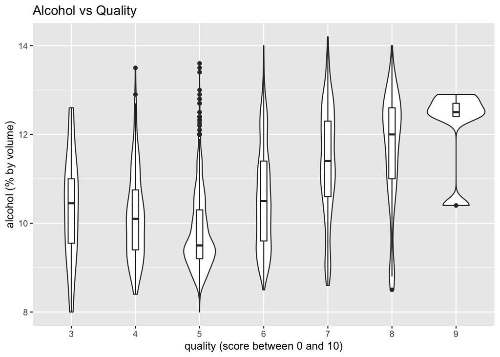

### 描述2

这张图以两种形式（箱型图和小提琴图）展示了 感兴趣的主要特性（质量） 和 与其相关性最高的其他特征（酒精度） 的关系。 可以看出酒精度高的酒往往质量越高。这一点在质量为9的白葡萄酒中体现尤为明显。而在质量为3的葡萄酒中酒精度的影响却显得不大。

## 绘图3

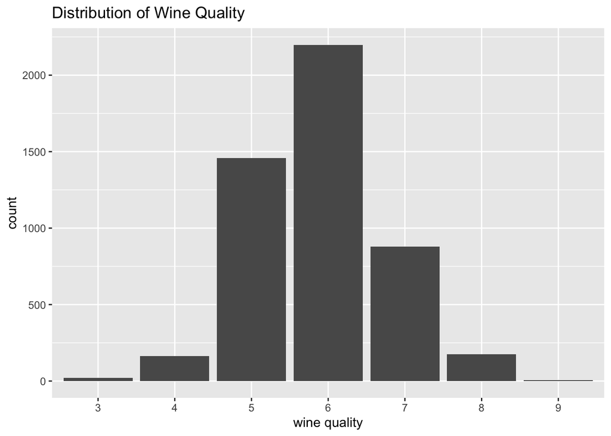

### 描述3

如图所示，本数据集中白葡萄酒的质量大致呈正态分布； 最小值为3，最大值为9（没有质量为0、1、2、10的酒）； 中位数和众数都为6。 或许可以以6为界限进行进一步的划分： 3<sub>5为低，6为中，7</sub>9为高。

# 反思

通过本次分析，我发现在这个数据集中：

大多数特征呈正态分布。 一些较强的偏态分布经过转化后，可以发现其他趋势。例如本次分析中的“剩余糖分”特征。

如果我在分析之前了解更多关于白葡萄酒的背景知识，相信本次分析的过程会更加顺畅。

可以在此次分析的基础上，建立一个用于预测白葡萄酒质量的监督学习模型。